# IP Weighting for Categorical Exposures

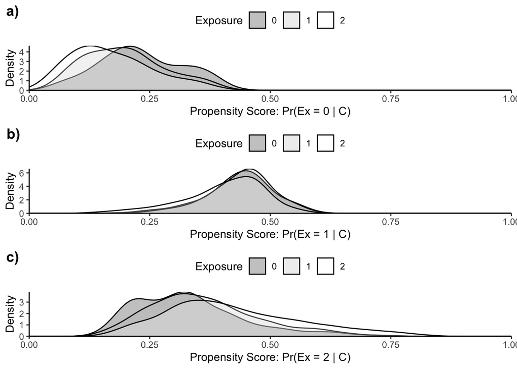

```r
plot_dat0 <- plot_dat %>%
  filter(pEx == "pEx0") %>%
  mutate(Exposure = factor(Exposure))

p1 <- ggplot(plot_dat0) +
  geom_density(aes(x = propensity_score,
                   group = Exposure,
                   fill  = Exposure),
               bw = .03, alpha = .25) +
  scale_x_continuous(expand = c(0,0), limits = c(0,1)) +
  scale_y_continuous(expand = c(0,0)) +
  scale_fill_manual(values = c("black", "gray", "white")) +
  xlab("Propensity Score: Pr(Ex = 0 | C)") + ylab("Density")

plot_dat1 <- plot_dat %>%
  filter(pEx == "pEx1") %>%
  mutate(Exposure = factor(Exposure))

p2 <- ggplot(plot_dat1) +
  geom_density(aes(x = propensity_score,
                   group = Exposure,
                   fill  = Exposure),
               bw = .03, alpha = .25) +
  scale_x_continuous(expand = c(0,0), limits = c(0,1)) +
  scale_y_continuous(expand = c(0,0)) +
  scale_fill_manual(values = c("black", "gray", "white")) +
  xlab("Propensity Score: Pr(Ex = 1 | C)") + ylab("Density")

plot_dat2 <- plot_dat %>%
  filter(pEx == "pEx2") %>%
  mutate(Exposure = factor(Exposure))

p3 <- ggplot(plot_dat2) +
  geom_density(aes(x = propensity_score,
                   group = Exposure,
                   fill  = Exposure),
               bw = .03, alpha = .25) +
  scale_x_continuous(expand = c(0,0), limits = c(0,1)) +
  scale_y_continuous(expand = c(0,0)) +
  scale_fill_manual(values = c("black", "gray", "white")) +
  xlab("Propensity Score: Pr(Ex = 2 | C)") + ylab("Density")

ggarrange(p1, p2, p3, ncol = 1, labels = c("a)", "b)", "c)"))
```

```r
ggsave(here("figures", "ps_overlap_plot_v2.png"),
       width = 8, height = 20, units = "cm")
```

This is a propensity score overlap plot for the categorical (three level) exposure, and it does not suggest problematic overlap. For a three category exposure, we can also use ternary plots to evaluate **joint** overlap in the distribution of the propensity score. Details on ternary plots are provided in the eAppendix of Yoshida et al (2019) Pharmacoepidemiol Drug Saf, Jul; 28(7): 934–941, section 3.1.

In R, ternary plots can be obtained using the `ggtern` package, which is available on CRAN. Documentation and examples are available [here](http://www.ggtern.com/d/2.2.0/demo-points.html).

We can use the `ps_matrix` data object to create our ternary plot. The basic formulation is as follows:

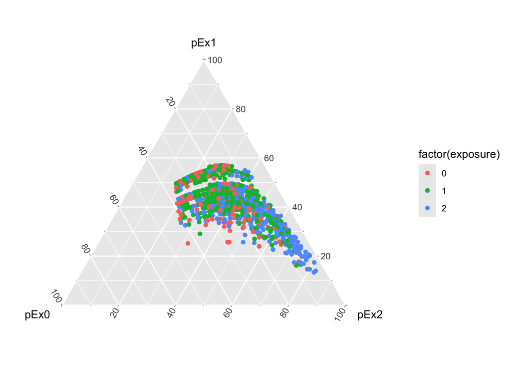

```r
pacman::p_load(ggtern)

# ternary plot
ggtern(data=ps_matrix,
       aes(x=pEx0,y=pEx1, z=pEx2)) +
  geom_point(aes(group = factor(exposure),
                 color = factor(exposure)))
```

This plot shows how the probabilities of being in each exposure category are jointly related among those in each observed exposure category. Further details, including how to convert propensity scores to “preference scores” (which account for the baseline prevalence of each exposure category) are available in the paper by Yoshida et al.

# Computing the Effect Contrasts

To construct stabilized weights used to estimate each of the parameters of interest outlined in the Classroom article, we need to obtain the predicted probability of the observed exposure from the propensity score matrix object:

```r
head(ps_matrix)
```

```
##         pEx0      pEx1      pEx2 exposure
## 1 0.17520860 0.3115711 0.5132203        2
## 2 0.32954521 0.3893255 0.2811293        0
## 3 0.03869395 0.2744873 0.6868187        2
## 4 0.05465770 0.1978439 0.7474984        2
## 5 0.29618176 0.4296766 0.2741417        1
## 6 0.05730343 0.2672524 0.6754441        1
```

```r
pscore_obs <- NULL
for(i in 1:nrow(ps_matrix)){
  pscore_obs <- rbind(pscore_obs,
                  ps_matrix[i, ps_matrix[i,]$exposure + 1] # note the "+ 1"
                  )
}

head(pscore_obs)
```

```
##           [,1]
## [1,] 0.5132203
## [2,] 0.3295452
## [3,] 0.6868187
## [4,] 0.7474984
## [5,] 0.4296766
## [6,] 0.2672524
```

Each row in the `pscore_obs` object represents the predicted probability for each person being in their **observed exposure level**, conditional on the covariates in the propensity score model. With this, we can construct inverse probability weight as we did above. Note that we can stabilize these weights by including the overall mean of the observed exposure category. We can actually do this simply with an intercept only multinomial model, as we did above:

```r
mean(nhefs$exercise == 0)
```

```
## [1] 0.194426
```

```r
mean(nhefs$exercise == 1)
```

```
## [1] 0.4253484
```

```r
mean(nhefs$exercise == 2)
```

```
## [1] 0.3802256
```

```r
ps_model <- vglm(factor(exercise) ~ 1,
               data = nhefs,
               family = "multinomial")

ps_num <- cbind(predict(ps_model, type = "response"),  nhefs$exercise)

ps_num <- data.frame(ps_num)

names(ps_num) <- c("p0", "p1", "p2", "exercise_level")

head(ps_num)
```

```
##         p0        p1        p2 exercise_level
## 1 0.194426 0.4253484 0.3802256              2
## 2 0.194426 0.4253484 0.3802256              0
## 3 0.194426 0.4253484 0.3802256              2
## 4 0.194426 0.4253484 0.3802256              2
## 5 0.194426 0.4253484 0.3802256              1
## 6 0.194426 0.4253484 0.3802256              1
```

```r
pscore_num <- NULL
for(i in 1:nrow(ps_num)){
  pscore_num <- rbind(pscore_num,
                      ps_num[i, ps_num[i,]$exercise_level + 1]
  )
}

head(pscore_num)
```

```
##           [,1]
## [1,] 0.3802256
## [2,] 0.1944260
## [3,] 0.3802256
## [4,] 0.3802256
## [5,] 0.4253484
## [6,] 0.4253484
```

```r
head(pscore_obs)
```

```
##           [,1]
## [1,] 0.5132203
## [2,] 0.3295452
## [3,] 0.6868187
## [4,] 0.7474984
## [5,] 0.4296766
## [6,] 0.2672524
```

```r
nhefs$sw_exercise <- pscore_num/pscore_obs

head(nhefs)
```

```
##         pEx0      pEx1      pEx2    wt82_71 exercise sex age race income school
## 1 0.17520860 0.3115711 0.5132203 -10.093960        2   0  42    1      1      7
## 2 0.32954521 0.3893255 0.2811293   2.604970        0   0  36    0      1      9
## 3 0.03869395 0.2744873 0.6868187   9.414486        2   1  56    1      0     11
## 4 0.05465770 0.1978439 0.7474984   4.990117        2   0  68    1      0      5
## 5 0.29618176 0.4296766 0.2741417   4.989251        1   0  40    0      1     11
## 6 0.05730343 0.2672524 0.6754441   4.419060        1   1  43    1      0      9
##   sw_exercise
## 1   0.7408625
## 2   0.5899828
## 3   0.5536040
## 4   0.5086641
## 5   0.9899269
## 6   1.5915603
```

```r
summary(nhefs$sw_exercise)
```

```
##        V1
##  Min.   :0.4518
##  1st Qu.:0.8148
##  Median :0.9367
##  Mean   :1.0003
##  3rd Qu.:1.1027
##  Max.   :3.6319
```

With these weights we can now estimate the average treatment affect between exercise and our outcome of interest (in this case, weight change). We use the `coeftest` function from the `lmtest` package along with the `sandwich` function to obtain robust variance estimates.

```r
modelRD_ex1 <- lm(wt82_71 ~ relevel(factor(exercise),
                                    ref = "2"),
                 weight = sw_exercise,
                 data = nhefs)

modelRD_ex2 <- lm(wt82_71 ~ relevel(factor(exercise),
                                    ref = "1"),
                 weight = sw_exercise,
                 data = nhefs)

coeftest(modelRD_ex1, vcov. = vcovHC(modelRD_ex1, "HC3"))
```

```
##
## t test of coefficients:
##
##                                         Estimate Std. Error t value  Pr(>|t|)
## (Intercept)                            2.6726241  0.3650777  7.3207 4.001e-13
## relevel(factor(exercise), ref = "2")0 -0.2213478  0.5827657 -0.3798    0.7041
## relevel(factor(exercise), ref = "2")1 -0.0025688  0.4746690 -0.0054    0.9957
##
## (Intercept)                           ***
## relevel(factor(exercise), ref = "2")0
## relevel(factor(exercise), ref = "2")1
## ---
## Signif. codes:  0 '***' 0.001 '**' 0.01 '*' 0.05 '.' 0.1 ' ' 1
```

```r
coefci(modelRD_ex1, vcov. = vcovHC(modelRD_ex1, "HC3"))
```

```
##                                            2.5 %    97.5 %
## (Intercept)                            1.9565087 3.3887396
## relevel(factor(exercise), ref = "2")0 -1.3644676 0.9217719
## relevel(factor(exercise), ref = "2")1 -0.9336524 0.9285147
```

```r
coeftest(modelRD_ex2, vcov. = vcovHC(modelRD_ex2, "HC3"))
```

```
##
## t test of coefficients:
##
##                                         Estimate Std. Error t value Pr(>|t|)
## (Intercept)                            2.6700553  0.3033628  8.8015   <2e-16
## relevel(factor(exercise), ref = "1")0 -0.2187790  0.5462263 -0.4005   0.6888
## relevel(factor(exercise), ref = "1")2  0.0025688  0.4746690  0.0054   0.9957
##
## (Intercept)                           ***
## relevel(factor(exercise), ref = "1")0
## relevel(factor(exercise), ref = "1")2
## ---
## Signif. codes:  0 '***' 0.001 '**' 0.01 '*' 0.05 '.' 0.1 ' ' 1
```

```r
coefci(modelRD_ex2, vcov. = vcovHC(modelRD_ex2, "HC3"))
```

```
##                                            2.5 %    97.5 %
## (Intercept)                            2.0749963 3.2651143
## relevel(factor(exercise), ref = "1")0 -1.2902251 0.8526671
## relevel(factor(exercise), ref = "1")2 -0.9285147 0.9336524
```

We also deploy the bootstrap here to account for variability in the propensity score model:

```r
pacman::p_load(boot)

boot_func <- function(data, index){

  boot_dat <- data[index,]

  # numerator model
  num_mod <- vglm(factor(exercise) ~ 1,
                 data = boot_dat,
                 family = "multinomial")

  # denominator model
  ps_mod <- vglm(factor(exercise) ~ sex + age + race + income + school,
                 data = boot_dat,
                 family = "multinomial")

  # denominator
  ps_matrix <- data.frame(predict(ps_mod, type = "response"),
                          exposure = boot_dat$exercise)
  pscore_obs <- NULL
  for(i in 1:nrow(ps_matrix)){
    pscore_obs <- rbind(pscore_obs,
                    ps_matrix[i, ps_matrix[i,]$exposure + 1] # note the "+ 1"
                    )
  }

  # numerator
  ps_matrix <- data.frame(predict(num_mod, type = "response"),
                          exposure = boot_dat$exercise)

  pscore_num <- NULL
  for(i in 1:nrow(ps_matrix)){
    pscore_num <- rbind(pscore_num,
                        ps_matrix[i, ps_matrix[i,]$exposure + 1]
    )
  }

  boot_dat$sw_exercise <- pscore_num/pscore_obs

  modelRD_ex1 <- lm(wt82_71 ~ relevel(factor(exercise),
                                      ref = "2"),
                   weight = sw_exercise,
                   data = boot_dat)

  modelRD_ex2 <- lm(wt82_71 ~ relevel(factor(exercise),
                                      ref = "1"),
                   weight = sw_exercise,
                   data = boot_dat)

  res1 <- summary(modelRD_ex1)$coefficients[2:3, 1]
  res2 <- summary(modelRD_ex2)$coefficients[2, 1]

  return(c(res1, res2))
}

boot_res <- boot::boot(nhefs, boot_func, R = 2000)

boot.ci(boot_res, type = "norm", index = 1)
```

```
## BOOTSTRAP CONFIDENCE INTERVAL CALCULATIONS
## Based on 2000 bootstrap replicates
##
## CALL :
## boot.ci(boot.out = boot_res, type = "norm", index = 1)
##
## Intervals :
## Level      Normal
## 95%   (-1.3018,  0.8785 )
## Calculations and Intervals on Original Scale
```

```r
boot.ci(boot_res, type = "norm", index = 2)
```

```
## BOOTSTRAP CONFIDENCE INTERVAL CALCULATIONS
## Based on 2000 bootstrap replicates
##
## CALL :
## boot.ci(boot.out = boot_res, type = "norm", index = 2)
##
## Intervals :
## Level      Normal
## 95%   (-0.9205,  0.9132 )
## Calculations and Intervals on Original Scale
```

```r
boot.ci(boot_res, type = "norm", index = 3)
```

```
## BOOTSTRAP CONFIDENCE INTERVAL CALCULATIONS
## Based on 2000 bootstrap replicates
##
## CALL :
## boot.ci(boot.out = boot_res, type = "norm", index = 3)
##
## Intervals :
## Level      Normal
## 95%   (-1.2037,  0.7878 )
## Calculations and Intervals on Original Scale
```